# notebook

Machine Learning Nanodegree Capstone Project

Stock Price Prediction with SVR and LSTM RNN -- A Comparative Approach

1. Import Modules and Data
2. Data Exploration and Preprocessing
3. Implement and Evaluate The SVR Model
4. Implement and Evaluate the LSTM Model

# 1. Import Modules and Data

## 1) Import required modules

main modules include numpy, sklearn, pandas, matplotlib

```python
import numpy as np
import matplotlib.pyplot as plt
import pandas as pd
from pandas import datetime
import math, time
import itertools
from sklearn.preprocessing import MinMaxScaler, StandardScaler
from sklearn.svm import SVR
import datetime
from operator import itemgetter
from sklearn.metrics import mean_squared_error
from math import sqrt
from keras.models import Sequential
from keras.layers.core import Dense, Dropout, Activation
from keras.layers.recurrent import LSTM
from keras.models import load_model
from keras.utils.vis_utils import plot_model
import keras
import h5py
import requests
import os
```

## 2) Read data and transform them to pandas dataframe

```python
df_origin = pd.read_csv("./input/GOOGL.csv", index_col = 0, parse_dates=['Date'])
df_origin = df_origin.rename(str.lower, axis='columns')
df_origin.head()
```

| Date | open | high | low | close | volume | adj close |
| --- | --- | --- | --- | --- | --- | --- |
| 2017-05-03 | 936.050000 | 950.200000 | 935.210000 | 948.450000 | 1824800 | 948.450000 |
| 2017-05-02 | 933.270020 | 942.989990 | 931.000000 | 937.090027 | 1748800 | 937.090027 |
| 2017-05-01 | 924.150024 | 935.820007 | 920.799988 | 932.820007 | 2323600 | 932.820007 |
| 2017-04-28 | 929.000000 | 935.900024 | 923.219971 | 924.520020 | 3797800 | 924.520020 |
| 2017-04-27 | 890.000000 | 893.380005 | 887.179993 | 891.440002 | 2158000 | 891.440002 |

## 3) Data cleasing

From empirical experience, we know that this dataset should not contain any NaN values. Checking to make sure that it's the case.

```python
df_origin.isnull().values.any()
```

```
False
```

## 4) Reverse the order in chronological order

```python
df_sorted = df_origin.sort_index(axis=0 ,ascending=True)
df_sorted.head()
```

| Date | open | high | low | close | volume | adj close |
| --- | --- | --- | --- | --- | --- | --- |
| 2009-05-22 | 198.528534 | 199.524521 | 196.196198 | 393.500000 | 3433700 | 196.946945 |
| 2009-05-26 | 391.950009 | 404.999995 | 389.999996 | 404.360011 | 6202700 | 202.382388 |
| 2009-05-27 | 405.640010 | 411.860011 | 404.810000 | 405.560012 | 6062500 | 202.982989 |
| 2009-05-28 | 408.679997 | 411.620017 | 404.610005 | 410.400016 | 5332200 | 205.405413 |
| 2009-05-29 | 412.110005 | 417.230002 | 410.700009 | 417.230002 | 5291100 | 208.823825 |

# 2. Data Exploration and Preprocessing

## 1) Statistical traits of the dataset

```python
print(df_sorted.mean(), df_sorted.std())
```

```
open         6.689058e+02
high         6.741916e+02
low          6.630564e+02
close        6.688434e+02
volume       4.088972e+06
adj close    4.661172e+02
dtype: float64 open         1.652566e+02
high         1.658896e+02
low          1.644025e+02
close        1.649341e+02
volume       2.840959e+06
adj close    1.972226e+02
dtype: float64
```

From the traits we can tell the volume is on a much larger scale than the rest of the features.

## 1) Visualize the stock price change since inception

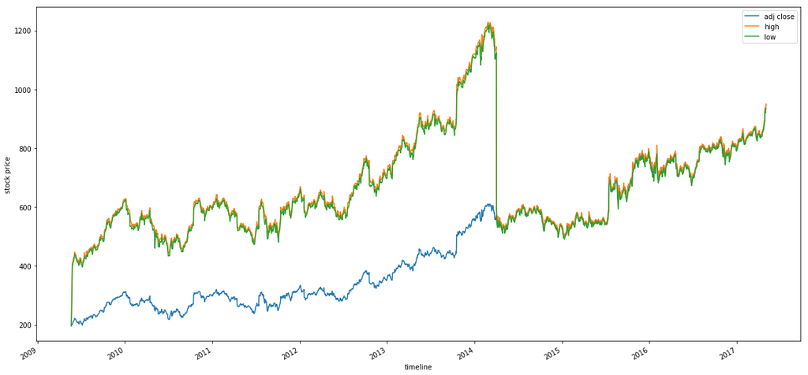

```python
df_sorted[['adj close', 'high', 'low']].plot(figsize=(20, 10))
plt.xlabel('timeline')
plt.ylabel('stock price')
plt.show()
```

## 2) Normalize the data

```python
# global scaler to denormalize the data for better visualization after evaluating the model
# standard_scaler for SVR model
standard_scaler = StandardScaler()
# min_max_scaler for RNN model
min_max_scaler = MinMaxScaler()

def normalize_data(scaler, df):
    df_new = df.copy()
    for symbol in df_new.columns:
        df_new[symbol] = scaler.fit_transform(df_new[symbol].values.reshape(-1,1))
    print(df_new.head())
    return df_new

df_normalized_std = normalize_data(standard_scaler, df_sorted)
df_normalized_minmax = normalize_data(min_max_scaler, df_sorted)
```

```
                open      high       low     close    volume  adj close
Date
2009-05-22 -2.847057 -2.862058 -2.840449 -1.669832 -0.230709  -1.365145
2009-05-26 -1.676333 -1.623121 -1.661317 -1.603971  0.744205  -1.337579
2009-05-27 -1.593471 -1.581758 -1.571210 -1.596694  0.694843  -1.334532
2009-05-28 -1.575071 -1.583205 -1.572427 -1.567342  0.437718  -1.322247
2009-05-29 -1.554310 -1.549379 -1.535375 -1.525921  0.423247  -1.304910
                open      high       low     close    volume  adj close
Date
2009-05-22  0.000000  0.000000  0.000000  0.000000  0.100109   0.000000
2009-05-26  0.188104  0.199616  0.189557  0.013137  0.195266   0.007233
2009-05-27  0.201417  0.206280  0.204042  0.014589  0.190448   0.008032
2009-05-28  0.204374  0.206047  0.203847  0.020443  0.165351   0.011255
2009-05-29  0.207709  0.211497  0.209803  0.028706  0.163939   0.015804
```

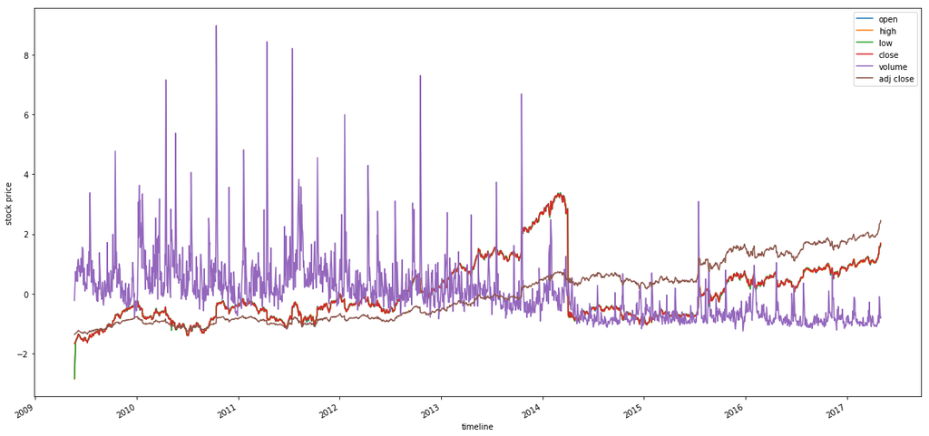

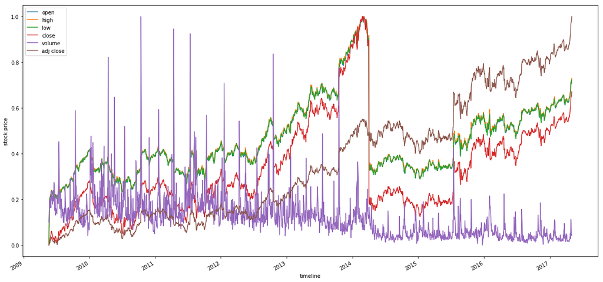

```python
def visualize_df(df_input, features=None):
    df_input[features or df_input.columns].plot(figsize=(20, 10))
    plt.xlabel('timeline')
    plt.ylabel('stock price')
    plt.show()
#visualize_df(df_normalized_std, features=['adj close', 'high', 'low'])
visualize_df(df_normalized_std)
visualize_df(df_normalized_minmax)
```

# 3. Implement and Evaluate The SVR Model

## 1) Choose technical indicators

the selected technical indicators include

[output not shown]

note:

- rolling average and rolling std are all critical part in calculating the bollinger band which provides good prediction on the range the stock price would oscillate
- Tr(t)=Max(Abs(High-Low), Abs(Hight-Close(t-1)), Abs(Low-Close(t-1)) Since the purpose of this project is for demonstrating the predictive power of a traditional regression model and the deep learning model in a comparative manner rather than to squeeze every bit of performance out of the models, only a selected few of technical indicators were utilized in training the model. Provided that adding more indicators could potentially improve the performance.

```python
# moving average
def calc_technical_indicators(df_input, window_size=10):
    df = df_input.copy()
    df['momentum'] = df['adj close'] - df['adj close'].shift(window_size)
    df['rolling average'] = df['adj close'].rolling(window_size).mean()
    df['rolling std'] = df['adj close'].rolling(window_size).std()
    df['tr1'] = abs (df['high'] - df['low'])
    df['tr2'] = abs (df['high'] - df['close'].shift())
    df['tr3'] = abs (df['low'] - df['close'].shift())
    df['true range'] = df[['tr1', 'tr2', 'tr3']].max(axis=1)
    df['average true range'] = df['true range'].ewm(span=window_size).mean()
#     df['tema'] = df['close'].ewm(span=10).mean()
    df = df.fillna(method='backfill')
    df = df.drop(columns=['tr1', 'tr2', 'tr3', 'true range'])
    return df
df_svr = calc_technical_indicators(df_normalized_std, 8)
df_svr.head(30)
```

| Date | open | high | low | close | volume | adj close | momentum | rolling average | rolling std | average true range |
| --- | --- | --- | --- | --- | --- | --- | --- | --- | --- | --- |
| 2009-05-22 | -2.847057 | -2.862058 | -2.840449 | -1.669832 | -0.230709 | -1.365145 | 0.118745 | -1.311313 | 0.034331 | 0.021610 |
| 2009-05-26 | -1.676333 | -1.623121 | -1.661317 | -1.603971 | 0.744205 | -1.337579 | 0.118745 | -1.311313 | 0.034331 | 0.035730 |
| 2009-05-27 | -1.593471 | -1.581758 | -1.571210 | -1.596694 | 0.694843 | -1.334532 | 0.118745 | -1.311313 | 0.034331 | 0.034484 |
| 2009-05-28 | -1.575071 | -1.583205 | -1.572427 | -1.567342 | 0.437718 | -1.322247 | 0.118745 | -1.311313 | 0.034331 | 0.030903 |
| 2009-05-29 | -1.554310 | -1.549379 | -1.535375 | -1.525921 | 0.423247 | -1.304910 | 0.118745 | -1.311313 | 0.034331 | 0.031233 |
| 2009-06-01 | -1.514241 | -1.474792 | -1.487736 | -1.469339 | 0.897502 | -1.281227 | 0.118745 | -1.311313 | 0.034331 | 0.036912 |
| 2009-06-02 | -1.468725 | -1.472622 | -1.458106 | -1.458180 | 0.405925 | -1.276556 | 0.118745 | -1.311313 | 0.034331 | 0.030900 |
| 2009-06-03 | -1.470238 | -1.457548 | -1.454455 | -1.438470 | 1.045517 | -1.268306 | 0.118745 | -1.311313 | 0.034331 | 0.023927 |
| 2009-06-04 | -1.413948 | -1.404608 | -1.390572 | -1.386133 | 1.119595 | -1.246400 | 0.118745 | -1.296470 | 0.033388 | 0.029873 |
| 2009-06-05 | -1.354813 | -1.367827 | -1.360394 | -1.361632 | 1.149627 | -1.236145 | 0.101434 | -1.283790 | 0.034778 | 0.028873 |
| 2009-06-08 | -1.388527 | -1.406537 | -1.392884 | -1.395291 | 0.740156 | -1.250233 | 0.084299 | -1.273253 | 0.029591 | 0.032676 |
| 2009-06-09 | -1.394095 | -1.409070 | -1.407242 | -1.414394 | 0.850006 | -1.258229 | 0.064018 | -1.265251 | 0.022176 | 0.028260 |
| 2009-06-10 | -1.408319 | -1.424807 | -1.438211 | -1.432709 | 0.923168 | -1.265895 | 0.039015 | -1.260374 | 0.015491 | 0.027233 |
| 2009-06-11 | -1.435314 | -1.449890 | -1.427868 | -1.454541 | 0.575875 | -1.275033 | 0.006194 | -1.259600 | 0.014418 | 0.026040 |
| 2009-06-12 | -1.465033 | -1.486249 | -1.471430 | -1.479770 | 0.613301 | -1.285593 | -0.009037 | -1.260729 | 0.016182 | 0.027329 |
| 2009-06-15 | -1.497475 | -1.523632 | -1.515297 | -1.528710 | 1.189096 | -1.306077 | -0.037771 | -1.265451 | 0.022846 | 0.031070 |
| 2009-06-16 | -1.510731 | -1.526104 | -1.506657 | -1.533380 | 0.705687 | -1.308032 | -0.061632 | -1.273155 | 0.025716 | 0.029038 |
| 2009-06-17 | -1.529615 | -1.534365 | -1.530142 | -1.538474 | 1.015484 | -1.310164 | -0.074019 | -1.282407 | 0.023738 | 0.023463 |
| 2009-06-18 | -1.532702 | -1.540576 | -1.521381 | -1.545145 | 0.730650 | -1.312956 | -0.062723 | -1.290247 | 0.021878 | 0.022507 |
| 2009-06-19 | -1.517389 | -1.529903 | -1.511768 | -1.508576 | 1.556423 | -1.297650 | -0.039421 | -1.295175 | 0.017672 | 0.024938 |
| 2009-06-22 | -1.525015 | -1.547811 | -1.588976 | -1.585839 | 1.461678 | -1.329989 | -0.064094 | -1.303187 | 0.017017 | 0.037326 |
| 2009-06-23 | -1.587358 | -1.599063 | -1.584961 | -1.595966 | 0.600098 | -1.334228 | -0.059195 | -1.310586 | 0.015857 | 0.032145 |
| 2009-06-24 | -1.574708 | -1.579527 | -1.560563 | -1.574073 | 0.289280 | -1.325064 | -0.039472 | -1.315520 | 0.012819 | 0.032871 |
| 2009-06-25 | -1.585240 | -1.557398 | -1.560867 | -1.534775 | 0.702026 | -1.308616 | -0.002538 | -1.315837 | 0.012581 | 0.029263 |
| 2009-06-26 | -1.544808 | -1.483053 | -1.520712 | -1.476859 | 0.851273 | -1.284374 | 0.023658 | -1.312880 | 0.016763 | 0.034263 |
| 2009-06-29 | -1.470238 | -1.485646 | -1.465164 | -1.484015 | 0.086340 | -1.287369 | 0.022795 | -1.310031 | 0.019069 | 0.031197 |
| 2009-06-30 | -1.482343 | -1.489203 | -1.489622 | -1.499479 | 0.385047 | -1.293842 | 0.019114 | -1.307642 | 0.019833 | 0.025504 |
| 2009-07-01 | -1.481133 | -1.494087 | -1.490048 | -1.515247 | 0.185874 | -1.300442 | -0.002792 | -1.307991 | 0.019655 | 0.021929 |
| 2009-07-02 | -1.534336 | -1.560353 | -1.559042 | -1.578925 | 0.331354 | -1.327095 | 0.002894 | -1.307629 | 0.019214 | 0.027083 |
| 2009-07-06 | -1.588266 | -1.589114 | -1.590375 | -1.572133 | 0.151968 | -1.324252 | 0.009976 | -1.306382 | 0.017488 | 0.023607 |

## 2) Create training set and testing set

```python
def create_train_test_datasets(df_input, window_size, features=[]):
    if features:
        number_of_features = len(features)
        dataset = df_input.copy()[features].values
    else:
        number_of_features = len(df_input.columns)
        dataset = df_input.copy().values
    window_size = window_size + 1
    result = []
    for index in range(len(dataset) - window_size): # maxmimum date = lastest date - sequence length
        result.append(dataset[index: index + window_size]) # index : index + 22days
    result = np.array(result)

    row = round(0.9 * result.shape[0]) # 90% split
    data_train = result[:int(row), :] # 90% date, all features

    X_train = data_train[:, :-1]
    y_train = data_train[:, -1][:,-1]
    print('Shapes: \n processed data : {}\n data_train - {}\n X_train - {}\n y_train : {}\n'.format(result.shape, data_train.shape, X_train.shape, y_train.shape))

    X_test = result[int(row):, :-1]
    y_test = result[int(row):, -1][:,-1]
    print('Shapes: \n X_test - {}\n y_test : {}\n'.format(X_test.shape, y_test.shape))

    X_train = np.reshape(X_train, (X_train.shape[0], X_train.shape[1], number_of_features))
    X_test = np.reshape(X_test, (X_test.shape[0], X_test.shape[1], number_of_features))
    print('X_train has a shape of {} | X_train sample at 1: \n{}'.format(X_train.shape, X_train[1]))
    print('y_train has a shape of {} | y_train sample at 1: \n{}'.format(y_train.shape, y_train[1]))

    return [X_train, y_train, X_test, y_test]
```

## 3) Implement the SVR Model

```python
# create the SVR model
svr = SVR(kernel='rbf', C=1, gamma=0.1, cache_size=200)
def transform_3d_to_2d(data_3d):
    dimensions = data_3d.shape
    data_2d = np.reshape(data_3d, (dimensions[0], dimensions[1] * dimensions[2]))
    return data_2d
X_train, y_train, X_test, y_test = create_train_test_datasets(df_svr.iloc[10:], 1, features=['momentum', 'rolling average', 'rolling std', 'average true range', 'adj close'])
X_train_2d = transform_3d_to_2d(X_train)
print(X_train_2d[1])
svr.fit(X_train_2d, y_train)
svr.get_params()
```

```
Shapes:
 processed data : (1989, 2, 5)
 data_train - (1790, 2, 5)
 X_train - (1790, 1, 5)
 y_train : (1790,)

Shapes:
 X_test - (199, 1, 5)
 y_test : (199,)

X_train has a shape of (1790, 1, 5) | X_train sample at 1:
[[ 0.06401788 -1.26525065  0.02217636  0.02825994 -1.25822886]]
y_train has a shape of (1790,) | y_train sample at 1:
-1.2658948026248575
[ 0.06401788 -1.26525065  0.02217636  0.02825994 -1.25822886]
```

```
{'C': 1,
 'cache_size': 200,
 'coef0': 0.0,
 'degree': 3,
 'epsilon': 0.1,
 'gamma': 0.1,
 'kernel': 'rbf',
 'max_iter': -1,
 'shrinking': True,
 'tol': 0.001,
 'verbose': False}
```

## 4) Calculate the performance score and visualize the results

```
the root mean squared error for training set is 9.207596297502324
the root mean squared error for test set is 33.59647918777672
```

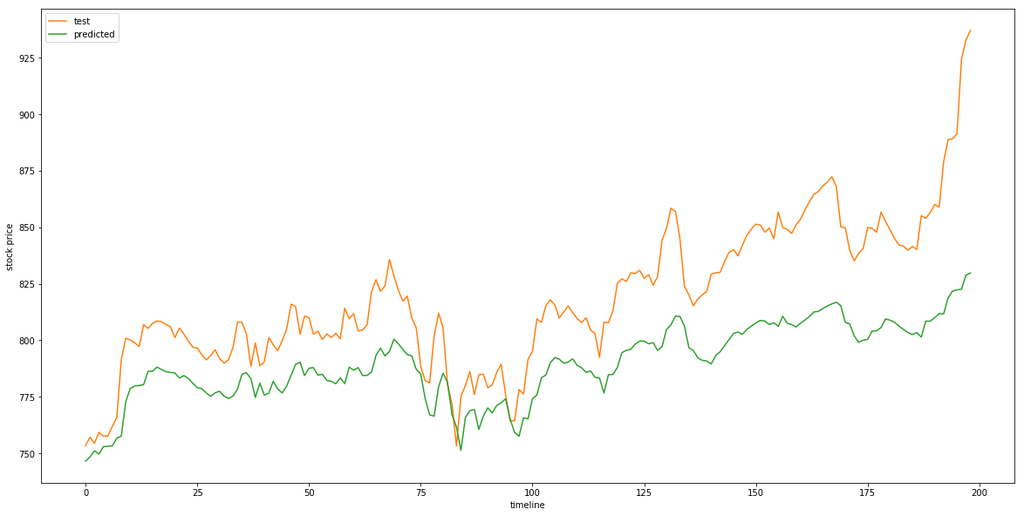

```python
X_test_2d = transform_3d_to_2d(X_test)
train_predict = svr.predict(X_train_2d)
test_predict = svr.predict(X_test_2d)

y_train_denom = standard_scaler.inverse_transform(y_train)
y_test_denorm = standard_scaler.inverse_transform(y_test)
train_predict_denom = standard_scaler.inverse_transform(train_predict)
test_predict_denorm = standard_scaler.inverse_transform(test_predict)

rmse_train = sqrt(mean_squared_error(y_train_denom, train_predict_denom))
print('the root mean squared error for training set is {}'.format(rmse_train))
rmse_test = sqrt(mean_squared_error(y_test_denorm, test_predict_denorm))
print('the root mean squared error for test set is {}'.format(rmse_test))

plt.figure(figsize=(20, 10))
plt.plot(y_test_denorm, color='C1', label='test')
plt.plot(test_predict_denorm, color='C2', label='predicted')
plt.xlabel('timeline')
plt.ylabel('stock price')
plt.legend(loc='upper left')
plt.show()
```

# 4. Implement and Evaluate the LSTM Model

## 1) Build the structure of model

```python
window_size_lstm = 1
num_of_features = len(df_normalized_minmax.columns)

def build_model(layers):
    d = 0.3
    model = Sequential()

    model.add(LSTM(256, input_shape=(layers[1], layers[0]), return_sequences=True))
    model.add(Dropout(d))

    model.add(LSTM(256, input_shape=(layers[1], layers[0]), return_sequences=False))
    model.add(Dropout(d))

    model.add(Dense(32,kernel_initializer="uniform",activation='relu'))
    model.add(Dense(1,kernel_initializer="uniform",activation='linear'))

    # adam = keras.optimizers.Adam(decay=0.2)

    start = time.time()
    model.compile(loss='mse',optimizer='adam', metrics=['accuracy'])
    print("Compilation Time : ", time.time() - start)
    return model

model = build_model([num_of_features, window_size_lstm])
model.summary()
plot_model(model)
```

```
Compilation Time :  0.017756223678588867
_________________________________________________________________
Layer (type)                 Output Shape              Param #
=================================================================
lstm_15 (LSTM)               (None, 1, 256)            269312
_________________________________________________________________
dropout_15 (Dropout)         (None, 1, 256)            0
_________________________________________________________________
lstm_16 (LSTM)               (None, 256)               525312
_________________________________________________________________
dropout_16 (Dropout)         (None, 256)               0
_________________________________________________________________
dense_15 (Dense)             (None, 32)                8224
_________________________________________________________________
dense_16 (Dense)             (None, 1)                 33
=================================================================
Total params: 802,881
Trainable params: 802,881
Non-trainable params: 0
_________________________________________________________________
```

## 2) Train the LSTM model

```python
X_train, y_train, X_test, y_test = create_train_test_datasets(df_normalized_minmax, window_size_lstm)
model.fit(X_train, y_train, batch_size=410, epochs=200, validation_split=0.1, verbose=1)
```

```
Shapes:
 processed data : (1999, 2, 6)
 data_train - (1799, 2, 6)
 X_train - (1799, 1, 6)
 y_train : (1799,)

Shapes:
 X_test - (200, 1, 6)
 y_test : (200,)

X_train has a shape of (1799, 1, 6) | X_train sample at 1:
[[0.1881035  0.19961566 0.189557   0.01313706 0.19526587 0.00723276]]
y_train has a shape of (1799,) | y_train sample at 1:
0.008031962025756512
Train on 1619 samples, validate on 180 samples
```

```
<keras.callbacks.History at 0x13cbb9208>
```

## 3) Denormalize the data, calculate the score and visualize the results

```
train score and test score are respectively 7.711845916677005 and 9.004305540494096
```

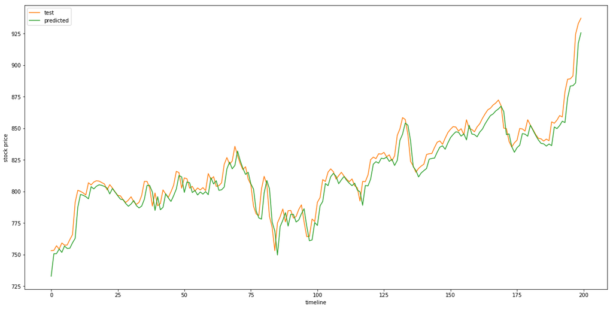

```python
train_predict = model.predict(X_train)
test_predict = model.predict(X_test)

y_train_denorm = min_max_scaler.inverse_transform(y_train.reshape(-1, 1))
train_predict_denorm = min_max_scaler.inverse_transform(train_predict)
y_test_denorm = min_max_scaler.inverse_transform(y_test.reshape(-1, 1))
test_predict_denorm = min_max_scaler.inverse_transform(test_predict)

# print(y_predict_denormalized[:5], '\n\n', y_test_denormalized[:5])
train_score = sqrt(mean_squared_error(y_train_denorm[:,0], train_predict_denorm[:,0]))
test_score = sqrt(mean_squared_error(y_test_denorm[:,0], test_predict_denorm[:,0]))
print('train score and test score are respectively {} and {}'.format(train_score, test_score))

plt.figure(figsize=(20, 10))
plt.plot(y_test_denorm, color='C1', label='test')
plt.plot(test_predict_denorm, color='C2', label='predicted')
plt.xlabel('timeline')
plt.ylabel('stock price')
plt.legend(loc='upper left')
plt.show()
```